# Практика 1. EDA, очистка данных и базовая модель классификации

**Выполнил:** Макеев Г. Б. **Группа:** BHEBDPS-24-MII-5 **Дисциплина:** Методы искусственного интеллекта **Датасет:** Telco Customer Churn (7043 записи, 21 признак) **Задача:** бинарная классификация — предсказать отток клиента (`Churn`: 1 — ушёл, 0 — остался)

**Главный принцип:** *Garbage In, Garbage Out* — качество данных важнее выбора модели.

### План работы

1. Первичный осмотр (EDA)
2. Очистка данных (Data Cleaning)
3. Визуализация и поиск инсайтов
4. Feature Engineering (кодирование признаков)
5. Обучение базовой модели `LogisticRegression`
6. Оценка качества: `classification_report`, `Confusion Matrix`, `ROC-AUC`
7. :star: Задания со звёздочкой: RandomForest / CatBoost, сравнение метрик, важность признаков

## 0. Импорт библиотек и настройки

```python
import warnings
warnings.filterwarnings("ignore")

import numpy as np
import pandas as pd
import matplotlib.pyplot as plt
import seaborn as sns

from sklearn.model_selection import train_test_split
from sklearn.preprocessing import StandardScaler
from sklearn.compose import ColumnTransformer
from sklearn.pipeline import Pipeline
from sklearn.linear_model import LogisticRegression
from sklearn.ensemble import RandomForestClassifier
from sklearn.metrics import (
    classification_report, confusion_matrix, ConfusionMatrixDisplay,
    roc_auc_score, roc_curve, accuracy_score, f1_score,
    precision_score, recall_score,
)

sns.set_theme(style="whitegrid")
plt.rcParams["figure.figsize"] = (9, 5)
plt.rcParams["font.size"] = 11
RANDOM_STATE = 42

print("Библиотеки загружены")
import sklearn
print("scikit-learn:", sklearn.__version__, "| pandas:", pd.__version__)
```

```
Библиотеки загружены
scikit-learn: 1.9.1 | pandas: 3.0.6
```

## Шаг 1. Первичный осмотр данных (EDA)

Смотрим первые строки, типы данных, пропуски и статистические сводки.

```python
df = pd.read_csv("data/Telco-Customer-Churn.csv")
print("Размер датасета:", df.shape)
df.head()
```

```
Размер датасета: (7043, 21)
```

|  | customerID | gender | SeniorCitizen | Partner | Dependents | tenure | PhoneService | MultipleLines | InternetService | OnlineSecurity | ... | DeviceProtection | TechSupport | StreamingTV | StreamingMovies | Contract | PaperlessBilling | PaymentMethod | MonthlyCharges | TotalCharges | Churn |
| --- | --- | --- | --- | --- | --- | --- | --- | --- | --- | --- | --- | --- | --- | --- | --- | --- | --- | --- | --- | --- | --- |
| 0 | 7590-VHVEG | Female | 0 | Yes | No | 1 | No | No phone service | DSL | No | ... | No | No | No | No | Month-to-month | Yes | Electronic check | 29.85 | 29.85 | No |
| 1 | 5575-GNVDE | Male | 0 | No | No | 34 | Yes | No | DSL | Yes | ... | Yes | No | No | No | One year | No | Mailed check | 56.95 | 1889.5 | No |
| 2 | 3668-QPYBK | Male | 0 | No | No | 2 | Yes | No | DSL | Yes | ... | No | No | No | No | Month-to-month | Yes | Mailed check | 53.85 | 108.15 | Yes |
| 3 | 7795-CFOCW | Male | 0 | No | No | 45 | No | No phone service | DSL | Yes | ... | Yes | Yes | No | No | One year | No | Bank transfer (automatic) | 42.30 | 1840.75 | No |
| 4 | 9237-HQITU | Female | 0 | No | No | 2 | Yes | No | Fiber optic | No | ... | No | No | No | No | Month-to-month | Yes | Electronic check | 70.70 | 151.65 | Yes |

5 rows × 21 columns

```python
df.info()
```

```
<class 'pandas.DataFrame'>
RangeIndex: 7043 entries, 0 to 7042
Data columns (total 21 columns):
 #   Column            Non-Null Count  Dtype
---  ------            --------------  -----
 0   customerID        7043 non-null   str
 1   gender            7043 non-null   str
 2   SeniorCitizen     7043 non-null   int64
 3   Partner           7043 non-null   str
 4   Dependents        7043 non-null   str
 5   tenure            7043 non-null   int64
 6   PhoneService      7043 non-null   str
 7   MultipleLines     7043 non-null   str
 8   InternetService   7043 non-null   str
 9   OnlineSecurity    7043 non-null   str
 10  OnlineBackup      7043 non-null   str
 11  DeviceProtection  7043 non-null   str
 12  TechSupport       7043 non-null   str
 13  StreamingTV       7043 non-null   str
 14  StreamingMovies   7043 non-null   str
 15  Contract          7043 non-null   str
 16  PaperlessBilling  7043 non-null   str
 17  PaymentMethod     7043 non-null   str
 18  MonthlyCharges    7043 non-null   float64
 19  TotalCharges      7043 non-null   str
 20  Churn             7043 non-null   str
dtypes: float64(1), int64(2), str(18)
memory usage: 1.1 MB
```

```python
df.describe(include="all").T
```

|  | count | unique | top | freq | mean | std | min | 25% | 50% | 75% | max |
| --- | --- | --- | --- | --- | --- | --- | --- | --- | --- | --- | --- |
| customerID | 7043 | 7043 | 7590-VHVEG | 1 | NaN | NaN | NaN | NaN | NaN | NaN | NaN |
| gender | 7043 | 2 | Male | 3555 | NaN | NaN | NaN | NaN | NaN | NaN | NaN |
| SeniorCitizen | 7043.0 | NaN | NaN | NaN | 0.162147 | 0.368612 | 0.0 | 0.0 | 0.0 | 0.0 | 1.0 |
| Partner | 7043 | 2 | No | 3641 | NaN | NaN | NaN | NaN | NaN | NaN | NaN |
| Dependents | 7043 | 2 | No | 4933 | NaN | NaN | NaN | NaN | NaN | NaN | NaN |
| tenure | 7043.0 | NaN | NaN | NaN | 32.371149 | 24.559481 | 0.0 | 9.0 | 29.0 | 55.0 | 72.0 |
| PhoneService | 7043 | 2 | Yes | 6361 | NaN | NaN | NaN | NaN | NaN | NaN | NaN |
| MultipleLines | 7043 | 3 | No | 3390 | NaN | NaN | NaN | NaN | NaN | NaN | NaN |
| InternetService | 7043 | 3 | Fiber optic | 3096 | NaN | NaN | NaN | NaN | NaN | NaN | NaN |
| OnlineSecurity | 7043 | 3 | No | 3498 | NaN | NaN | NaN | NaN | NaN | NaN | NaN |
| OnlineBackup | 7043 | 3 | No | 3088 | NaN | NaN | NaN | NaN | NaN | NaN | NaN |
| DeviceProtection | 7043 | 3 | No | 3095 | NaN | NaN | NaN | NaN | NaN | NaN | NaN |
| TechSupport | 7043 | 3 | No | 3473 | NaN | NaN | NaN | NaN | NaN | NaN | NaN |
| StreamingTV | 7043 | 3 | No | 2810 | NaN | NaN | NaN | NaN | NaN | NaN | NaN |
| StreamingMovies | 7043 | 3 | No | 2785 | NaN | NaN | NaN | NaN | NaN | NaN | NaN |
| Contract | 7043 | 3 | Month-to-month | 3875 | NaN | NaN | NaN | NaN | NaN | NaN | NaN |
| PaperlessBilling | 7043 | 2 | Yes | 4171 | NaN | NaN | NaN | NaN | NaN | NaN | NaN |
| PaymentMethod | 7043 | 4 | Electronic check | 2365 | NaN | NaN | NaN | NaN | NaN | NaN | NaN |
| MonthlyCharges | 7043.0 | NaN | NaN | NaN | 64.761692 | 30.090047 | 18.25 | 35.5 | 70.35 | 89.85 | 118.75 |
| TotalCharges | 7043 | 6531 | 20.2 | 11 | NaN | NaN | NaN | NaN | NaN | NaN | NaN |
| Churn | 7043 | 2 | No | 5174 | NaN | NaN | NaN | NaN | NaN | NaN | NaN |

### Ловушка датасета

```python
print("Тип TotalCharges до очистки:", df["TotalCharges"].dtype)

# Сколько значений не приводится к числу
converted = pd.to_numeric(df["TotalCharges"], errors="coerce")
print("Нечисловых значений в TotalCharges:", converted.isna().sum())

# Что это за строки?
df[converted.isna()][["customerID", "tenure", "MonthlyCharges", "TotalCharges", "Churn"]]
```

```
Тип TotalCharges до очистки: str
Нечисловых значений в TotalCharges: 11
```

|  | customerID | tenure | MonthlyCharges | TotalCharges | Churn |
| --- | --- | --- | --- | --- | --- |
| 488 | 4472-LVYGI | 0 | 52.55 |  | No |
| 753 | 3115-CZMZD | 0 | 20.25 |  | No |
| 936 | 5709-LVOEQ | 0 | 80.85 |  | No |
| 1082 | 4367-NUYAO | 0 | 25.75 |  | No |
| 1340 | 1371-DWPAZ | 0 | 56.05 |  | No |
| 3331 | 7644-OMVMY | 0 | 19.85 |  | No |
| 3826 | 3213-VVOLG | 0 | 25.35 |  | No |
| 4380 | 2520-SGTTA | 0 | 20.00 |  | No |
| 5218 | 2923-ARZLG | 0 | 19.70 |  | No |
| 6670 | 4075-WKNIU | 0 | 73.35 |  | No |
| 6754 | 2775-SEFEE | 0 | 61.90 |  | No |

**Вывод:** «пустые» значения `TotalCharges` — это абоненты с `tenure = 0`, то есть клиенты, которые ещё не пользовались услугами ни одного дня. Логично заполнить их нулём (совокупные платежи за 0 месяцев = 0), а не удалять строки.

## Шаг 2. Очистка данных (Data Cleaning)

1. Приведение `TotalCharges` к `float64` и заполнение пропусков.
2. Проверка и удаление дубликатов.
3. Удаление бесполезного признака `customerID`.

```python
df_clean = df.copy()

# 1) TotalCharges -> float64, пустые строки -> NaN
df_clean["TotalCharges"] = pd.to_numeric(df_clean["TotalCharges"], errors="coerce")
print("Пропусков после to_numeric:", df_clean["TotalCharges"].isna().sum())

# Заполняем нулём: tenure=0 => клиент ещё ничего не заплатил
df_clean["TotalCharges"] = df_clean["TotalCharges"].fillna(0.0)
print("Тип TotalCharges после очистки:", df_clean["TotalCharges"].dtype)
print("Пропусков в датасете всего:", int(df_clean.isna().sum().sum()))

# 2) Дубликаты
print("Полных дубликатов строк:", df_clean.duplicated().sum())
df_clean = df_clean.drop_duplicates().reset_index(drop=True)

# 3) Удаляем бесполезный идентификатор
df_clean = df_clean.drop(columns=["customerID"])
print("Размер после очистки:", df_clean.shape)
```

```
Пропусков после to_numeric: 11
Тип TotalCharges после очистки: float64
Пропусков в датасете всего: 0
Полных дубликатов строк: 0
Размер после очистки: (7043, 20)
```

## Шаг 3. Визуализация и поиск инсайтов

### 3.1 Распределение целевой переменной — есть ли дисбаланс классов?

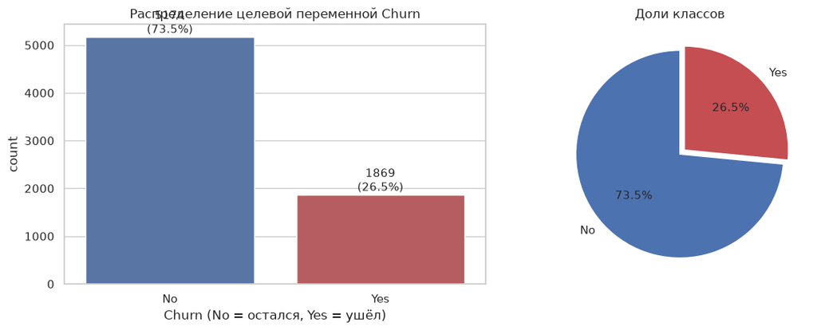

```
Churn
No     0.73463
Yes    0.26537
```

```python
fig, axes = plt.subplots(1, 2, figsize=(12, 4.5))

# countplot для Churn
sns.countplot(data=df_clean, x="Churn", ax=axes[0], palette=["#4C72B0", "#C44E52"])
axes[0].set_title("Распределение целевой переменной Churn")
axes[0].set_xlabel("Churn (No = остался, Yes = ушёл)")
for p in axes[0].patches:
    axes[0].annotate(f"{int(p.get_height())}\n({p.get_height()/len(df_clean):.1%})",
                     (p.get_x() + p.get_width()/2, p.get_height()),
                     ha="center", va="bottom", fontsize=11)

# доли классов
share = df_clean["Churn"].value_counts(normalize=True)
axes[1].pie(share, labels=share.index, autopct="%1.1f%%",
            colors=["#4C72B0", "#C44E52"], startangle=90, explode=(0, 0.06))
axes[1].set_title("Доли классов")

plt.tight_layout()
plt.show()

print(share.to_string())
```

**Инсайт:** классы несбалансированы — «ушло» примерно четверть клиентов (~26.5%). Это означает, что **Accuracy вводит в заблуждение**: модель, всегда предсказывающая «остался», даст ~73% accuracy, но не найдёт ни одного ушедшего. Поэтому используем Precision / Recall / F1 / ROC-AUC.

### 3.2 Сравнение групп: как отличаются платежи (MonthlyCharges, tenure) у ушедших и оставшихся?

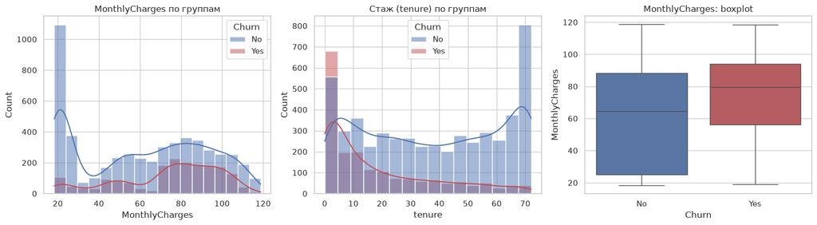

```
       tenure  MonthlyCharges  TotalCharges
Churn
No      37.57           61.27       2549.91
Yes     17.98           74.44       1531.80
```

```python
fig, axes = plt.subplots(1, 3, figsize=(16, 4.5))

sns.histplot(data=df_clean, x="MonthlyCharges", hue="Churn", kde=True,
             palette=["#4C72B0", "#C44E52"], ax=axes[0], alpha=0.5)
axes[0].set_title("MonthlyCharges по группам")

sns.histplot(data=df_clean, x="tenure", hue="Churn", kde=True,
             palette=["#4C72B0", "#C44E52"], ax=axes[1], alpha=0.5)
axes[1].set_title("Стаж (tenure) по группам")

sns.boxplot(data=df_clean, x="Churn", y="MonthlyCharges",
            palette=["#4C72B0", "#C44E52"], ax=axes[2])
axes[2].set_title("MonthlyCharges: boxplot")

plt.tight_layout()
plt.show()

print(df_clean.groupby("Churn")[["tenure", "MonthlyCharges", "TotalCharges"]].mean().round(2).to_string())
```

**Инсайты:**

- Уходящие клиенты платят **больше** в месяц (в среднем ~74 против ~61).
- Уходящие имеют гораздо **меньший стаж**: максимум уходов — в первые месяцы.
- Значит `MonthlyCharges`, `tenure`, `TotalCharges` — потенциально сильные признаки.

### 3.3 Дисбаланс по типу контракта (важный бизнес-фактор)

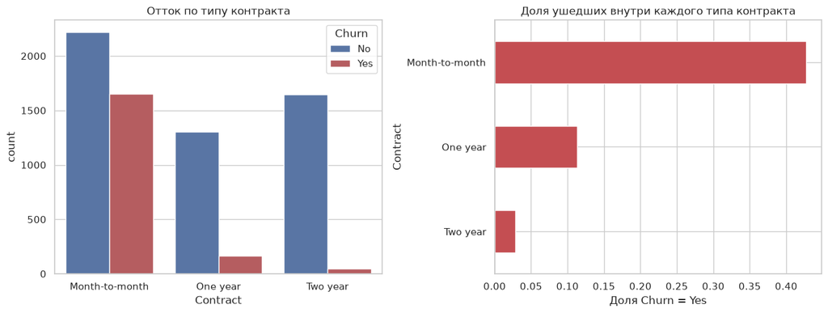

```
Churn              No    Yes
Contract
Month-to-month  0.573  0.427
One year        0.887  0.113
Two year        0.972  0.028
```

```python
fig, axes = plt.subplots(1, 2, figsize=(13, 5))

sns.countplot(data=df_clean, x="Contract", hue="Churn",
              palette=["#4C72B0", "#C44E52"], ax=axes[0])
axes[0].set_title("Отток по типу контракта")

ct = pd.crosstab(df_clean["Contract"], df_clean["Churn"], normalize="index")
ct["Yes"].sort_values().plot(kind="barh", color="#C44E52", ax=axes[1])
axes[1].set_title("Доля ушедших внутри каждого типа контракта")
axes[1].set_xlabel("Доля Churn = Yes")

plt.tight_layout()
plt.show()
print(ct.round(3).to_string())
```

**Инсайт:** клиенты на контракте `Month-to-month` уходят чаще всего (~43%). Долгосрочные контракты (One year, Two year) резко снижают отток — сильный предиктор.

### 3.4 Корреляционная матрица числовых признаков (heatmap)

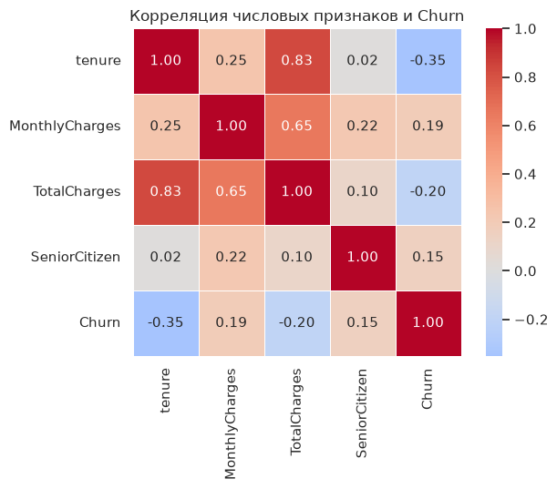

```python
num_cols = ["tenure", "MonthlyCharges", "TotalCharges", "SeniorCitizen"]
corr_df = df_clean[num_cols].copy()
corr_df["Churn"] = (df_clean["Churn"] == "Yes").astype(int)

plt.figure(figsize=(7, 5.5))
sns.heatmap(corr_df.corr(), annot=True, fmt=".2f", cmap="coolwarm",
            center=0, square=True, linewidths=0.5)
plt.title("Корреляция числовых признаков и Churn")
plt.tight_layout()
plt.show()
```

**Инсайт:** `tenure` отрицательно коррелирует с оттоком (чем дольше клиент — тем реже уходит), `MonthlyCharges` — положительно. `TotalCharges` сильно связан с `tenure` (мультиколлинеарность). Прямые линейные корреляции слабые, поэтому нужны категориальные признаки и нелинейные модели.

## Шаг 4. Feature Engineering (создание признаков)

Модели понимают только числа, поэтому кодируем категориальные признаки:

- **Label Encoding** — для бинарных `Yes/No` и пола (`Male/Female`).
- **One-Hot Encoding** — для многозначных (`InternetService`, `PaymentMethod`, `Contract` и т.д.).

```python
# Разделяем признаки на группы
target = "Churn"

binary_cols = [c for c in df_clean.columns
               if df_clean[c].nunique() == 2 and c != target]
print("Бинарные признаки (Label Encoding):", binary_cols)

numeric_cols = ["tenure", "MonthlyCharges", "TotalCharges"]
print("Числовые признаки (StandardScaler):", numeric_cols)

multi_cols = [c for c in df_clean.select_dtypes(include="object").columns
              if c not in binary_cols and c != target]
print("Многозначные категориальные (One-Hot):", multi_cols)
```

```
Бинарные признаки (Label Encoding): ['gender', 'SeniorCitizen', 'Partner', 'Dependents', 'PhoneService', 'PaperlessBilling']
Числовые признаки (StandardScaler): ['tenure', 'MonthlyCharges', 'TotalCharges']
Многозначные категориальные (One-Hot): ['MultipleLines', 'InternetService', 'OnlineSecurity', 'OnlineBackup', 'DeviceProtection', 'TechSupport', 'StreamingTV', 'StreamingMovies', 'Contract', 'PaymentMethod']
```

```python
# y: бинарный таргет, X: признаки
y = (df_clean[target] == "Yes").astype(int)
X = df_clean.drop(columns=[target])
```

Ручная демонстрация Label Encoding на бинарных признаках (наглядно, что Yes/No -> 1/0) плюс `pd.get_dummies` для контроля результата One-Hot.

```python
# Демонстрация Label Encoding: Yes/No -> 1/0, Male/Female -> 1/0
label_demo = X.copy()
for col in binary_cols:
    vals = sorted(label_demo[col].unique())
    mapping = {vals[0]: 0, vals[1]: 1}
    label_demo[col] = label_demo[col].map(mapping)
print("После Label Encoding (пример):")
print(label_demo[binary_cols].head())

# Демонстрация One-Hot через pandas
ohe_demo = pd.get_dummies(X, columns=multi_cols, drop_first=False)
print("\nРазмер после pd.get_dummies:", ohe_demo.shape)

# Проверим, что все столбцы числовые
print("Осталось нечисловых столбцов:", ohe_demo.select_dtypes(exclude=np.number).shape[1])
```

```
После Label Encoding (пример):
   gender  SeniorCitizen  Partner  Dependents  PhoneService  PaperlessBilling
0       0              0        1           0             0                 1
1       1              0        0           0             1                 0
2       1              0        0           0             1                 1
3       1              0        0           0             0                 0
4       0              0        0           0             1                 1

Размер после pd.get_dummies: (7043, 40)
Осталось нечисловых столбцов: 36
```

## Шаг 5. Разделение, масштабирование и обучение LogisticRegression

Собираем `Pipeline`: препроцессинг (`ColumnTransformer`) + модель. Это защищает от утечки данных (scaler обучается только на train).

```python
from sklearn.preprocessing import OneHotEncoder

# Бинарные признаки кодируем в 0/1 (Label Encoding)
X_enc = X.copy()
for col in binary_cols:
    vals = sorted(X_enc[col].unique())
    X_enc[col] = X_enc[col].map({vals[0]: 0, vals[1]: 1})

X_train, X_test, y_train, y_test = train_test_split(
    X_enc, y, test_size=0.2, random_state=RANDOM_STATE, stratify=y
)
print("Train:", X_train.shape, "| Test:", X_test.shape)
print("Доля Churn в train:", round(y_train.mean(), 4), "| в test:", round(y_test.mean(), 4))

# Препроцессор: числа -> StandardScaler, бинарные уже 0/1 -> passthrough, многозначные -> One-Hot
preprocessor = ColumnTransformer(
    transformers=[
        ("num", StandardScaler(), numeric_cols),
        ("bin", "passthrough", binary_cols),
        ("cat", OneHotEncoder(handle_unknown="ignore"), multi_cols),
    ]
)

log_reg = Pipeline(steps=[
    ("prep", preprocessor),
    ("model", LogisticRegression(max_iter=1000, random_state=RANDOM_STATE)),
])

log_reg.fit(X_train, y_train)
print("Модель обучена.")
```

```
Train: (5634, 19) | Test: (1409, 19)
Доля Churn в train: 0.2654 | в test: 0.2654
Модель обучена.
```

## Шаг 6. Оценка качества: почему Accuracy врёт?

Считаем `classification_report`, `Confusion Matrix` и `ROC-AUC`.

```python
y_pred = log_reg.predict(X_test)
y_proba = log_reg.predict_proba(X_test)[:, 1]

acc = accuracy_score(y_test, y_pred)
prec = precision_score(y_test, y_pred)
rec = recall_score(y_test, y_pred)
f1 = f1_score(y_test, y_pred)
roc = roc_auc_score(y_test, y_proba)

print(f"Accuracy : {acc:.4f}")
print(f"Precision: {prec:.4f}")
print(f"Recall   : {rec:.4f}")
print(f"F1-score : {f1:.4f}")
print(f"ROC-AUC  : {roc:.4f}")
print("\n" + "=" * 60)
print(classification_report(y_test, y_pred, target_names=["Остался (0)", "Ушёл (1)"]))
```

```
Accuracy : 0.8055
Precision: 0.6572
Recall   : 0.5588
F1-score : 0.6040
ROC-AUC  : 0.8420

============================================================
              precision    recall  f1-score   support

 Остался (0)       0.85      0.89      0.87      1035
    Ушёл (1)       0.66      0.56      0.60       374

    accuracy                           0.81      1409
   macro avg       0.75      0.73      0.74      1409
weighted avg       0.80      0.81      0.80      1409
```

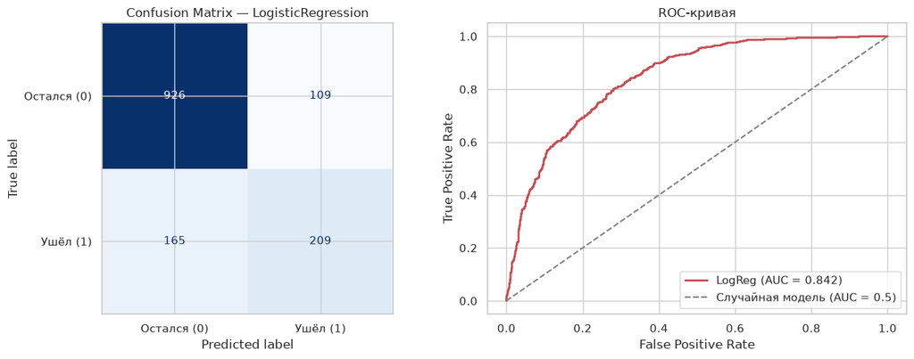

```python
fig, axes = plt.subplots(1, 2, figsize=(13, 5))

# Confusion Matrix
cm = confusion_matrix(y_test, y_pred)
disp = ConfusionMatrixDisplay(cm, display_labels=["Остался (0)", "Ушёл (1)"])
disp.plot(ax=axes[0], cmap="Blues", colorbar=False)
axes[0].set_title("Confusion Matrix — LogisticRegression")

# ROC-кривая
fpr, tpr, _ = roc_curve(y_test, y_proba)
axes[1].plot(fpr, tpr, color="#C44E52", lw=2, label=f"LogReg (AUC = {roc:.3f})")
axes[1].plot([0, 1], [0, 1], "--", color="gray", label="Случайная модель (AUC = 0.5)")
axes[1].set_xlabel("False Positive Rate")
axes[1].set_ylabel("True Positive Rate")
axes[1].set_title("ROC-кривая")
axes[1].legend(loc="lower right")

plt.tight_layout()
plt.show()
```

**Разбор матрицы ошибок (LogisticRegression):**

|  | предсказано «остался» | предсказано «ушёл» |
| --- | --- | --- |
| **реально остался** | TN — верно | FP — ложная тревога |
| **реально ушёл** | FN — пропустили уход | TP — верно поймали |

Наш `Recall` (~0.55) означает: модель находит лишь около половины реально уходящих клиентов. Именно **FN самые дорогие** в бизнесе — потерянного клиента уже не удержать. Accuracy (~0.80) при этом выглядит «хорошо», хотя это следствие дисбаланса классов.

## Шаг 7 :star: Ансамбли: Random Forest и CatBoost

Заменяем базовую модель на ансамбли и сравниваем метрики.

```python
# --- Random Forest ---
rf = Pipeline(steps=[
    ("prep", preprocessor),
    ("model", RandomForestClassifier(
        n_estimators=300, max_depth=None, random_state=RANDOM_STATE, n_jobs=-1)),
])
rf.fit(X_train, y_train)
y_pred_rf = rf.predict(X_test)
y_proba_rf = rf.predict_proba(X_test)[:, 1]

# --- CatBoost ---
from catboost import CatBoostClassifier
cb = Pipeline(steps=[
    ("prep", preprocessor),
    ("model", CatBoostClassifier(
        iterations=500, learning_rate=0.05, depth=6,
        random_seed=RANDOM_STATE, verbose=0)),
])
cb.fit(X_train, y_train)
y_pred_cb = cb.predict(X_test).ravel()
y_proba_cb = cb.predict_proba(X_test)[:, 1]

def metrics(name, y_true, y_pred, y_proba):
    return {
        "Модель": name,
        "Accuracy": accuracy_score(y_true, y_pred),
        "Precision": precision_score(y_true, y_pred),
        "Recall": recall_score(y_true, y_pred),
        "F1": f1_score(y_true, y_pred),
        "ROC-AUC": roc_auc_score(y_true, y_proba),
    }

results = pd.DataFrame([
    metrics("LogisticRegression", y_test, y_pred, y_proba),
    metrics("RandomForest", y_test, y_pred_rf, y_proba_rf),
    metrics("CatBoost", y_test, y_pred_cb, y_proba_cb),
]).set_index("Модель").round(4)

results
```

| Модель | Accuracy | Precision | Recall | F1 | ROC-AUC |
| --- | --- | --- | --- | --- | --- |
| LogisticRegression | 0.8055 | 0.6572 | 0.5588 | 0.6040 | 0.8420 |
| RandomForest | 0.7864 | 0.6197 | 0.5053 | 0.5567 | 0.8229 |
| CatBoost | 0.7935 | 0.6343 | 0.5241 | 0.5739 | 0.8369 |

### Сравнение метрик F1 и ROC-AUC визуально

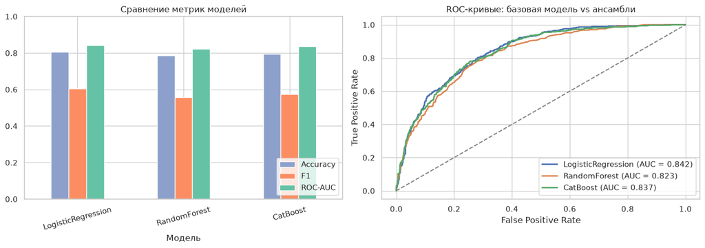

```python
fig, axes = plt.subplots(1, 2, figsize=(14, 5))

# Столбчатое сравнение F1 / ROC-AUC
results[["Accuracy", "F1", "ROC-AUC"]].plot(kind="bar", ax=axes[0],
                                            color=["#8DA0CB", "#FC8D62", "#66C2A5"])
axes[0].set_title("Сравнение метрик моделей")
axes[0].set_ylim(0, 1)
axes[0].legend(loc="lower right")
axes[0].tick_params(axis="x", rotation=15)

# ROC-кривые всех моделей
for name, proba, color in [
    ("LogisticRegression", y_proba, "#4C72B0"),
    ("RandomForest", y_proba_rf, "#DD8452"),
    ("CatBoost", y_proba_cb, "#55A868"),
]:
    fpr, tpr, _ = roc_curve(y_test, proba)
    axes[1].plot(fpr, tpr, lw=2, color=color,
                 label=f"{name} (AUC = {roc_auc_score(y_test, proba):.3f})")
axes[1].plot([0, 1], [0, 1], "--", color="gray")
axes[1].set_xlabel("False Positive Rate")
axes[1].set_ylabel("True Positive Rate")
axes[1].set_title("ROC-кривые: базовая модель vs ансамбли")
axes[1].legend(loc="lower right")

plt.tight_layout()
plt.show()
```

**Вывод по звёздочке — стало ли лучше?**

На этом датасете — **нет, не лучше**: `LogisticRegression` обошла ансамбли по всем ключевым метрикам (F1 ≈ 0.60 и ROC-AUC ≈ 0.842 против F1 ≈ 0.56 у RandomForest и ≈ 0.57 у CatBoost).

Почему так:

- после One-Hot признаки во многом линейно разделимы, а `LogisticRegression` со `StandardScaler` — очень крепкий baseline для Telco Churn;
- ансамбли с дефолтными гиперпараметрами на небольшой выборке (5634 train) склонны переобучаться (`RandomForest` — из-за глубоких деревьев, `CatBoost` — без тюнинга);
- дисбаланс классов одинаково давит Recall у всех моделей.

Что стоит попробовать, чтобы ансамбли «выиграли»:

- тюнинг гиперпараметров (`GridSearchCV`/Optuna: `max_depth`, `n_estimators`, `learning_rate`);
- балансировка классов (`class_weight="balanced"` для RF и LogReg, `scale_pos_weight`/`auto_class_weights` для CatBoost);
- подбор порога классификации под бизнес-метрику (Recall/F1);
- feature engineering: число подключённых услуг, флаг наличия поддержки и т.п.

**Главный урок:** ансамбль — не гарантия улучшения. Выбор модели нужно проверять на конкретных данных и метриках, а не выбирать «по умолчанию». При этом важность признаков у ансамблей подтверждает выводы EDA (см. ниже).

### :star: Важность признаков (feature_importances_)

Какой фактор главный для оттока?

```
ТОП-15 самых важных признаков (RandomForest):
TotalCharges                      0.1678
MonthlyCharges                    0.1457
tenure                            0.1433
Contract_Month-to-month           0.0623
TechSupport_No                    0.0313
OnlineSecurity_No                 0.0304
gender                            0.0284
InternetService_Fiber optic       0.0281
PaymentMethod_Electronic check    0.0280
PaperlessBilling                  0.0255
Partner                           0.0230
SeniorCitizen                     0.0199
Dependents                        0.0189
OnlineBackup_No                   0.0186
Contract_Two year                 0.0173
```

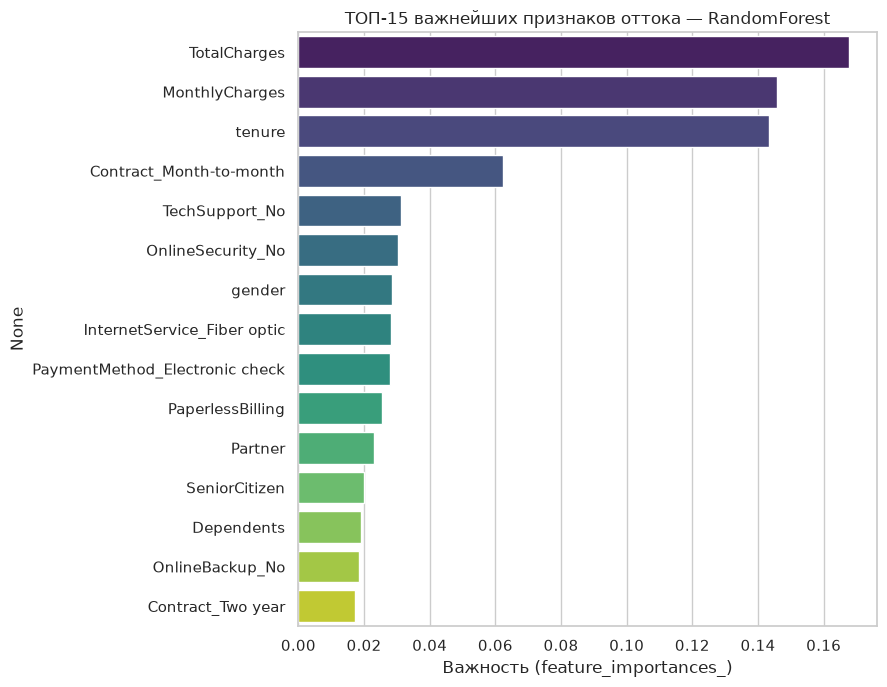

```python
# Имена признаков после препроцессинга
prep = rf.named_steps["prep"]
ohe_names = prep.named_transformers_["cat"].get_feature_names_out(multi_cols)
feature_names = numeric_cols + binary_cols + list(ohe_names)

importances = rf.named_steps["model"].feature_importances_
imp = (pd.Series(importances, index=feature_names)
       .sort_values(ascending=False))

print("ТОП-15 самых важных признаков (RandomForest):")
print(imp.head(15).round(4).to_string())

plt.figure(figsize=(9, 7))
sns.barplot(x=imp.head(15).values, y=imp.head(15).index,
            palette="viridis", hue=imp.head(15).index, legend=False)
plt.xlabel("Важность (feature_importances_)")
plt.title("ТОП-15 важнейших признаков оттока — RandomForest")
plt.tight_layout()
plt.show()
```

```python
# Важность признаков у CatBoost для сравнения
cb_model = cb.named_steps["model"]
cb_imp = pd.Series(cb_model.get_feature_importance(), index=feature_names).sort_values(ascending=False)
print("ТОП-10 признаков (CatBoost):")
print(cb_imp.head(10).round(3).to_string())
```

```
ТОП-10 признаков (CatBoost):
MonthlyCharges                    15.175
TotalCharges                      14.674
tenure                            14.580
Contract_Month-to-month            5.396
Contract_Two year                  4.622
PaperlessBilling                   3.902
gender                             3.572
PaymentMethod_Electronic check     2.673
Dependents                         2.285
OnlineSecurity_No                  2.160
```

**Ответ на вопрос «какой фактор главный?»**

**Бизнес-вывод:** удержание через перевод клиентов с `Month-to-month` на срочные контракты и подключение поддерживающих услуг (TechSupport, OnlineSecurity) — наиболее очевидные рычаги снижения оттока.

## Итоги

| Шаг | Что сделано |
| --- | --- |
| EDA | Изучены распределения, дисбаланс классов (~26.5% ушедших), связи с `tenure`/`MonthlyCharges` |
| Cleaning | `TotalCharges` → `float64`, пустые значения (tenure=0) заполнены 0, дубликаты и `customerID` удалены |
| Feature Eng. | Бинарные — Label Encoding, многозначные — One-Hot, числа — StandardScaler (всё внутри `Pipeline`) |
| Модель | `LogisticRegression` (baseline), затем `RandomForest` и `CatBoost` — baseline оказался лучше |
| Оценка | `classification_report`, `Confusion Matrix`, ROC-AUC; сравнение F1/ROC-AUC; важность признаков |

**Главный принцип соблюдён:** чистка и корректная подготовка признаков дали осмысленную модель, а метрики выбраны с учётом дисбаланса (F1, Recall, ROC-AUC), а не только Accuracy.